# Cross-sectional MLM: ECLS-K

Veronica Cole

Monday, May 14, 2018

We are using data from the Early Childhood Longitudinal Study (ECLS-K), a nationally representative study of children starting in kindergarten. For these analyses, we are looking solely at third grade data. Our variables are: **S5.ID** (a school-level identifier); **TVHours** (the average number of hours of TV watched after dinner, as reported by parents); **ClassSize** (the size of the child’s third-grade class, as reported by teachers); **ReadingScore** (the child’s IRT score on a standardized reading assessment); and **PctFRL** (the percentage of children at the child’s school qualifying for free or reduced lunch, a frequently used proxy for poverty).

We load in the package **lme4**, which is the basic machinery we’ll use to fit MLMs, as well as two packages for plotting: **ggplot2** and **car**.

Let’s take a look at the data.

```r
library(lme4)
library(ggplot2)
library(car)

ecls<-read.table("C:/Users/vcole/Dropbox/multilevel_new/ECLS-K.dat",header=TRUE,na=".")
names(ecls)<-c("S5.ID","TVHours","ClassSize","ReadingScore","PctFRL")

head(ecls)
```

```
##   S5.ID TVHours ClassSize ReadingScore PctFRL
## 1  9997       0        NA           NA     NA
## 2  6009       1        20        96.74  45.56
## 3  7197      NA        20        92.20  30.04
## 4  6026       2        19        95.33   0.00
## 5  6027       0        NA        63.73     NA
## 6  9997       0        NA           NA     NA
```

### Naive linear regression

First, let’s fit a naive linear regression predicting **ReadingScore** from **TvHours** – i.e., let’s ignore any potential nesting within school and simply fit a linear regression. As you can see, we get a steady decline in performance as the number of hours of TV goes up. But **we aren’t taking into account potential differences between schools**.

```r
naive.lr<-summary(lm(ReadingScore~TVHours,data=ecls))
hours<-1:6

naive.lr
```

```
##
## Call:
## lm(formula = ReadingScore ~ TVHours, data = ecls)
##
## Residuals:
##     Min      1Q  Median      3Q     Max
## -56.358 -12.496   2.864  13.826  37.922
##
## Coefficients:
##             Estimate Std. Error t value Pr(>|t|)
## (Intercept)  87.4480     0.2290  381.92   <2e-16 ***
## TVHours      -2.3220     0.1954  -11.89   <2e-16 ***
## ---
## Signif. codes:  0 '***' 0.001 '**' 0.01 '*' 0.05 '.' 0.1 ' ' 1
##
## Residual standard error: 17.63 on 12371 degrees of freedom
##   (2931 observations deleted due to missingness)
## Multiple R-squared:  0.01129,    Adjusted R-squared:  0.01121
## F-statistic: 141.3 on 1 and 12371 DF,  p-value: < 2.2e-16
```

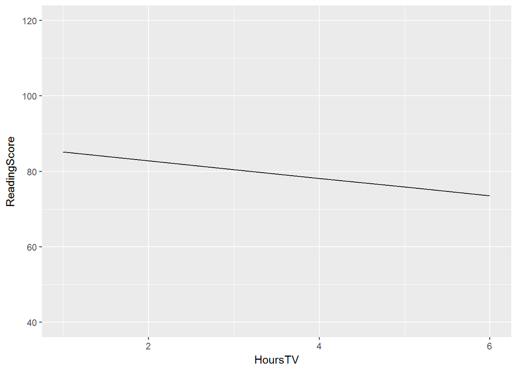

```r
ggplot(data.frame(HoursTV=hours,ReadingScore=naive.lr$coef[1,1]+naive.lr$coef[2,1]*hours),aes(x=HoursTV,y=ReadingScore)) + geom_line() + scale_y_continuous(limits=c(40,120))
```

### Random-effects ANOVA

Now, we will run a **random-effects ANOVA** to get our ICC. This will help us see how much variance is at the level of individual schools. The ICC is calculated as: $ICC = \frac{78.84}{78.84+247.04} = .242$ So we can say that roughly 24.2% of the variance in reading score owes to differences between schools.

```r
random.effects.anova<-lmer(ReadingScore~1+(1|S5.ID),data=ecls)
summary(random.effects.anova)
```

```
## Linear mixed model fit by REML ['lmerMod']
## Formula: ReadingScore ~ 1 + (1 | S5.ID)
##    Data: ecls
##
## REML criterion at convergence: 122095
##
## Scaled residuals:
##     Min      1Q  Median      3Q     Max
## -3.4276 -0.6644  0.1082  0.7224  2.7011
##
## Random effects:
##  Groups   Name        Variance Std.Dev.
##  S5.ID    (Intercept)  78.84    8.879
##  Residual             247.04   15.718
## Number of obs: 14373, groups: S5.ID, 2894
##
## Fixed effects:
##             Estimate Std. Error t value
## (Intercept)  83.7564     0.2491   336.3
```

### Random-intercept model

Now, we run a random-intercept model which, as its name implies, allows only the overall intercept of ReadingScore to vary between schools.

```r
random.intercept<-lmer(ReadingScore~TVHours+(1|S5.ID),data=ecls)
summary(random.intercept)
```

```
## Linear mixed model fit by REML ['lmerMod']
## Formula: ReadingScore ~ TVHours + (1 | S5.ID)
##    Data: ecls
##
## REML criterion at convergence: 104884.7
##
## Scaled residuals:
##     Min      1Q  Median      3Q     Max
## -3.5684 -0.6504  0.1163  0.7258  2.5932
##
## Random effects:
##  Groups   Name        Variance Std.Dev.
##  S5.ID    (Intercept)  72.52    8.516
##  Residual             242.86   15.584
## Number of obs: 12373, groups: S5.ID, 2579
##
## Fixed effects:
##             Estimate Std. Error t value
## (Intercept)  85.9533     0.2995  287.03
## TVHours      -1.4332     0.1853   -7.74
##
## Correlation of Fixed Effects:
##         (Intr)
## TVHours -0.524
```

We then use the results to plot model-implied relationships betweeen TVHours and ReadingScore for a subset of schools, chosen randomly. Note that **each line represents a different school**.

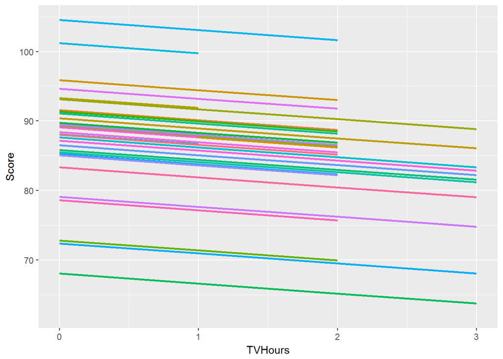

```r
random.list<-c(351,455,621,862,1119,2092,7015,7261,630,1212,379,7309,907,7054,367,6290,7015,7261,630,1212,379,7309,907,7054,367,6290,1194,1271,1280,2078,3070,7393,11,85,227,314,518,766,947,1211,2120,3094,53)
fitted1<-fitted(random.intercept)

output1<-merge(fitted1,ecls,by="row.names",all.x=TRUE)
names(output1)[2]<-"Score"
output1<-output1[order(output1$S5.ID),]
output1<-subset(output1,output1$S5.ID%in%random.list)


p1 <- ggplot(output1, aes(x = TVHours, y = Score, colour = factor(S5.ID))) + xlim(0,3) +
  geom_line(size=1) +
  theme(legend.position="none")

p1
```

### Adding predictors

Now let’s add in **PctFRL**, the percentage of students receiving free lunch at school *j*, as a level-2 predictor. First, we use it to predict the intercept, in an intercepts-as-outcomes model. Note that this means that **PctFRL** affects only the overall reading score for a given school.

```r
intercepts.as.outcomes<-lmer(ReadingScore~TVHours+PctFRL+(1|S5.ID),data=ecls)
summary(intercepts.as.outcomes)
```

```
## Linear mixed model fit by REML ['lmerMod']
## Formula: ReadingScore ~ TVHours + PctFRL + (1 | S5.ID)
##    Data: ecls
##
## REML criterion at convergence: 82281.8
##
## Scaled residuals:
##     Min      1Q  Median      3Q     Max
## -3.5190 -0.6629  0.1232  0.7369  2.5944
##
## Random effects:
##  Groups   Name        Variance Std.Dev.
##  S5.ID    (Intercept)  30.27    5.502
##  Residual             243.64   15.609
## Number of obs: 9780, groups: S5.ID, 1596
##
## Fixed effects:
##              Estimate Std. Error t value
## (Intercept) 92.479684   0.385306  240.02
## TVHours     -1.092445   0.205967   -5.30
## PctFRL      -0.202250   0.008283  -24.42
##
## Correlation of Fixed Effects:
##         (Intr) TVHors
## TVHours -0.404
## PctFRL  -0.644 -0.077
```

Now, we run a slopes-as-outcomes model. This allows different schools to have different slopes, each affected by PctFRL.

```r
slopes.as.outcomes<-lmer(ReadingScore~TVHours+PctFRL+PctFRL:TVHours+(TVHours|S5.ID),data=ecls)
summary(slopes.as.outcomes)
```

```
## Linear mixed model fit by REML ['lmerMod']
## Formula: ReadingScore ~ TVHours + PctFRL + PctFRL:TVHours + (TVHours |
##     S5.ID)
##    Data: ecls
##
## REML criterion at convergence: 82273.7
##
## Scaled residuals:
##     Min      1Q  Median      3Q     Max
## -3.5163 -0.6572  0.1182  0.7342  2.5556
##
## Random effects:
##  Groups   Name        Variance Std.Dev. Corr
##  S5.ID    (Intercept)  32.995   5.744
##           TVHours       3.504   1.872   -0.31
##  Residual             241.414  15.538
## Number of obs: 9780, groups: S5.ID, 1596
##
## Fixed effects:
##                 Estimate Std. Error t value
## (Intercept)    93.132070   0.439641  211.84
## TVHours        -1.905685   0.331645   -5.75
## PctFRL         -0.222057   0.010455  -21.24
## TVHours:PctFRL  0.022706   0.007215    3.15
##
## Correlation of Fixed Effects:
##             (Intr) TVHors PctFRL
## TVHours     -0.601
## PctFRL      -0.729  0.424
## TVHrs:PcFRL  0.466 -0.754 -0.613
```

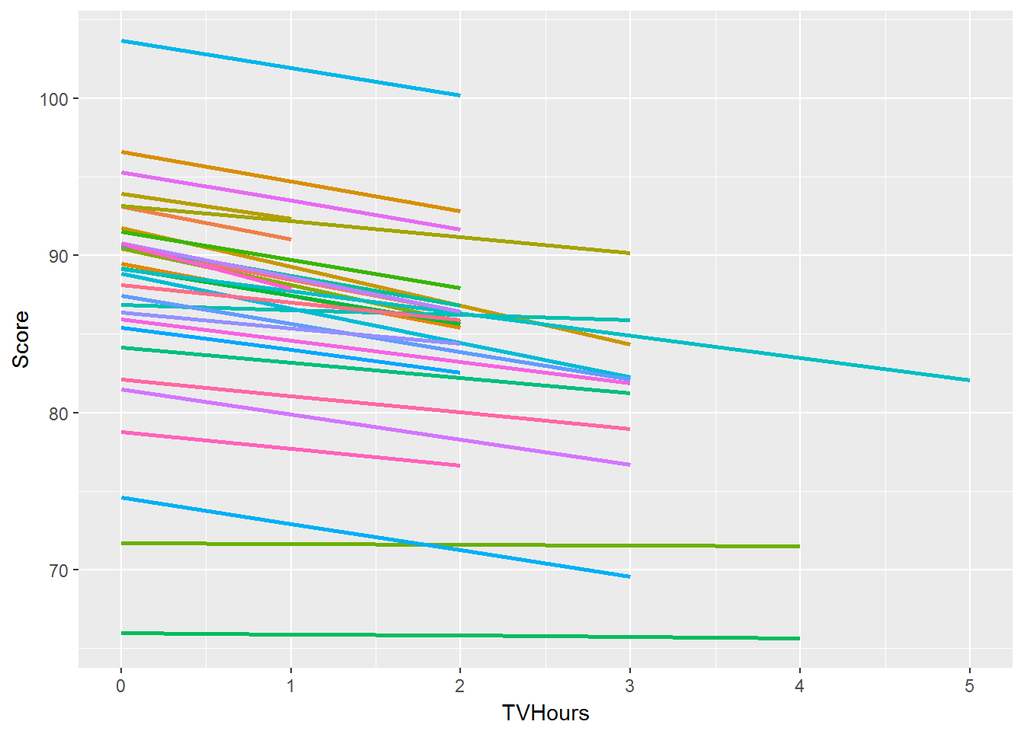

### Hypothesis testing

We use the **anova** command to test the relative fit of each model. **Models have to be nested within one another for this to work.** First, we test whether adding PctFRL as a predictor of the intercept improved the fit of the model, relative to the random-intercept model. We then test whether allowing slopes to also be affected by PctFRL led to a significant increase in fit.

```r
anova(intercepts.as.outcomes,random.intercept)
```

```
## Data: ecls
## Models:
## random.intercept: ReadingScore ~ TVHours + (1 | S5.ID)
## intercepts.as.outcomes: ReadingScore ~ TVHours + PctFRL + (1 | S5.ID)
##                        Df    AIC    BIC logLik deviance Chisq Chi Df
## random.intercept        4 104890 104920 -52441   104882
## intercepts.as.outcomes  5  82282  82318 -41136    82272 22611      1
##                        Pr(>Chisq)
## random.intercept
## intercepts.as.outcomes  < 2.2e-16 ***
## ---
## Signif. codes:  0 '***' 0.001 '**' 0.01 '*' 0.05 '.' 0.1 ' ' 1
```

```r
anova(slopes.as.outcomes,intercepts.as.outcomes)
```

```
## Data: ecls
## Models:
## intercepts.as.outcomes: ReadingScore ~ TVHours + PctFRL + (1 | S5.ID)
## slopes.as.outcomes: ReadingScore ~ TVHours + PctFRL + PctFRL:TVHours + (TVHours |
## slopes.as.outcomes:     S5.ID)
##                        Df   AIC   BIC logLik deviance  Chisq Chi Df
## intercepts.as.outcomes  5 82282 82318 -41136    82272
## slopes.as.outcomes      8 82272 82329 -41128    82256 16.089      3
##                        Pr(>Chisq)
## intercepts.as.outcomes
## slopes.as.outcomes       0.001088 **
## ---
## Signif. codes:  0 '***' 0.001 '**' 0.01 '*' 0.05 '.' 0.1 ' ' 1
```

### Diagnostics

First, we examine linearity. We use the **scatter.smooth** function from the **cars** package to see the general shape of the relationship between TVHours and ReadingScore. We see that it is roughly linear, or at least close enough that we are not concerned.

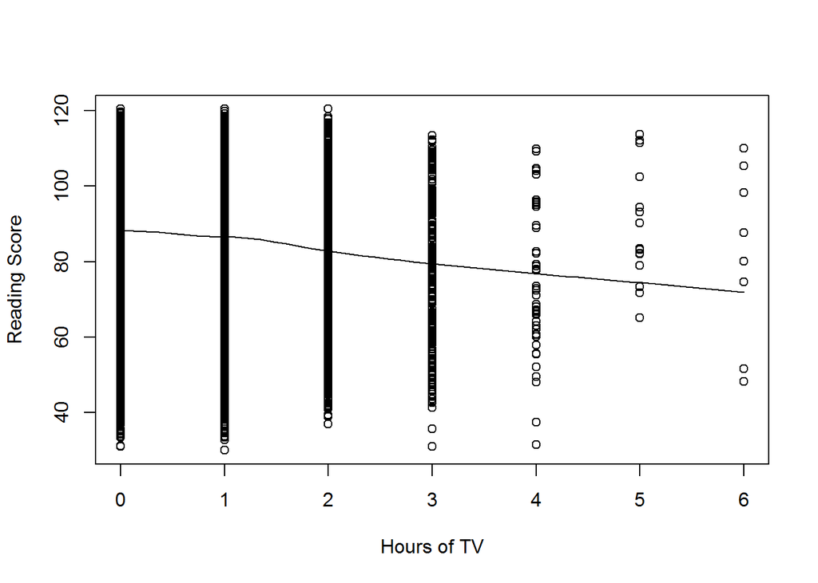

```r
scatter.smooth(ecls$ReadingScore~ecls$TVHours,ylab="Reading Score",xlab="Hours of TV")
```

Second, we examine the normality of residuals. We do this using our old friend from Intro Grad Stat, the QQ-plot.

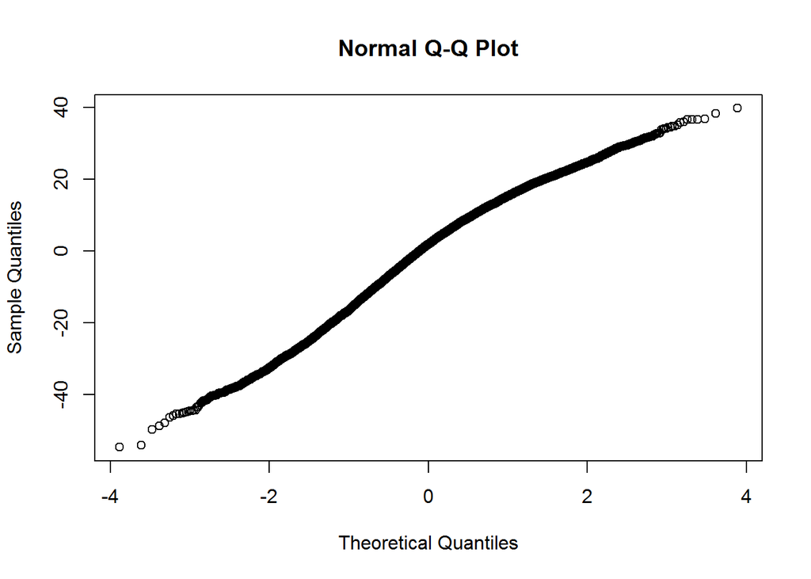

```r
qqnorm(residuals(slopes.as.outcomes))
```

Finally, we test for homoscedasticity of residuals using Levene’s test.

```r
getresids<-merge(residuals(slopes.as.outcomes),ecls,by="row.names")
names(getresids)[2]<-"Residuals"
levene<-lm(Residuals ~ S5.ID, data=getresids)
anova(levene)
```

```
## Analysis of Variance Table
##
## Response: Residuals
##             Df  Sum Sq Mean Sq F value Pr(>F)
## S5.ID        1     247  246.52   1.089 0.2967
## Residuals 9778 2213464  226.37
```